# Pruébate

1. Lee en dos dataframes: **gpd** y **unemployment**, respectivamente almacenan por país el PIB por persona empleado y la tasa de desempleo desde 1991.

El PIB por persona empleado es el producto interno bruto dividido por el total de personas empleadas en la economía.

El desempleo se refiere a la proporción de la fuerza laboral que no tiene trabajo, pero que está disponible y en busca de empleo.

```python
# Librerias
import pandas as pd
import numpy as np
import matplotlib.pyplot as plt
import seaborn as sns

# Dataframes

gdp = pd.read_csv('GDP.csv')
unemployment = pd.read_csv('Unemployment.csv')
```

```python
gdp
```

|  | Country Name | Country Code | 1991 | 1992 | 1993 | 1994 | 1995 | 1996 | 1997 | 1998 | ... | 2010 | 2011 | 2012 | 2013 | 2014 | 2015 | 2016 | 2017 | 2018 | 2019 |
| --- | --- | --- | --- | --- | --- | --- | --- | --- | --- | --- | --- | --- | --- | --- | --- | --- | --- | --- | --- | --- | --- |
| 0 | Aruba | ABW | NaN | NaN | NaN | NaN | NaN | NaN | NaN | NaN | ... | NaN | NaN | NaN | NaN | NaN | NaN | NaN | NaN | NaN | NaN |
| 1 | Afghanistan | AFG | NaN | NaN | NaN | NaN | NaN | NaN | NaN | NaN | ... | 8948.946623 | 8617.407888 | 9262.492619 | 9292.956732 | 9063.896306 | 8754.304860 | 8578.345113 | 8456.651850 | 8238.098259 | 8246.351581 |
| 2 | Angola | AGO | 14384.761840 | 13120.133350 | 9642.526050 | 9461.039214 | 10538.582010 | 11603.523630 | 12053.947920 | 12211.188950 | ... | 20750.617000 | 20250.418470 | 21209.387460 | 21475.279260 | 21704.449360 | 21126.640140 | 19854.887150 | 19125.640200 | 18079.185140 | 17339.271710 |
| 3 | Albania | ALB | 9013.241061 | 8369.953690 | 9436.839108 | 10484.991210 | 12285.389740 | 13580.983120 | 11832.935020 | 13051.716560 | ... | 29728.235970 | 27056.594940 | 28608.461540 | 31721.082180 | 32838.340220 | 31715.691870 | 31448.227580 | 31589.094090 | 31104.970770 | 31009.390130 |
| 4 | Andorra | AND | NaN | NaN | NaN | NaN | NaN | NaN | NaN | NaN | ... | NaN | NaN | NaN | NaN | NaN | NaN | NaN | NaN | NaN | NaN |
| ... | ... | ... | ... | ... | ... | ... | ... | ... | ... | ... | ... | ... | ... | ... | ... | ... | ... | ... | ... | ... | ... |
| 259 | Kosovo | XKX | NaN | NaN | NaN | NaN | NaN | NaN | NaN | NaN | ... | NaN | NaN | NaN | NaN | NaN | NaN | NaN | NaN | NaN | NaN |
| 260 | Yemen, Rep. | YEM | NaN | NaN | NaN | NaN | NaN | NaN | NaN | NaN | ... | NaN | NaN | NaN | NaN | NaN | NaN | NaN | NaN | NaN | NaN |
| 261 | South Africa | ZAF | 41361.508100 | 39246.581870 | 38596.134760 | 38670.153560 | 38704.861750 | 39347.107290 | 39372.931790 | 38602.303040 | ... | 44791.331600 | 45457.344970 | 45288.140820 | 44937.397170 | 44920.168390 | 43809.448460 | 43994.506750 | 43735.453270 | 43502.930740 | 43799.052020 |
| 262 | Zambia | ZMB | 6243.900822 | 6010.665459 | 6298.992905 | 5504.707529 | 5417.893299 | 5511.472882 | 5455.573886 | 5184.548351 | ... | 8909.948626 | 8879.129000 | 9058.300351 | 9271.103438 | 9450.238557 | 9469.911445 | 9575.027135 | 9649.520081 | 9734.154281 | 9522.766264 |
| 263 | Zimbabwe | ZWE | 8015.204821 | 7104.256815 | 7013.554097 | 7502.436034 | 7417.443389 | 8126.261564 | 8303.709804 | 8514.776679 | ... | 4984.150204 | 5622.864438 | 6465.352627 | 6490.533197 | 6538.270852 | 6548.899397 | 6498.134879 | 6691.393263 | 6891.794071 | 6213.323493 |

264 rows × 31 columns

```python
unemployment
```

|  | Country Name | Country Code | 1991 | 1992 | 1993 | 1994 | 1995 | 1996 | 1997 | 1998 | ... | 2010 | 2011 | 2012 | 2013 | 2014 | 2015 | 2016 | 2017 | 2018 | 2019 |
| --- | --- | --- | --- | --- | --- | --- | --- | --- | --- | --- | --- | --- | --- | --- | --- | --- | --- | --- | --- | --- | --- |
| 0 | Aruba | ABW | NaN | NaN | NaN | NaN | NaN | NaN | NaN | NaN | ... | NaN | NaN | NaN | NaN | NaN | NaN | NaN | NaN | NaN | NaN |
| 1 | Afghanistan | AFG | 11.380000 | 11.46 | 11.610000 | 11.650000 | 11.650000 | 11.650000 | 11.640000 | 11.640000 | ... | 11.52 | 11.510000 | 11.52 | 11.540000 | 11.450000 | 11.390000 | 11.310000 | 11.180000 | 11.06 | 10.980000 |
| 2 | Angola | AGO | 3.750000 | 3.78 | 3.850000 | 3.870000 | 3.860000 | 3.860000 | 3.860000 | 3.860000 | ... | 9.43 | 7.360000 | 7.37 | 7.380000 | 7.310000 | 7.260000 | 7.200000 | 7.100000 | 7.00 | 6.930000 |
| 3 | Albania | ALB | 16.219999 | 16.33 | 16.520000 | 16.570000 | 16.570000 | 16.570000 | 16.549999 | 16.549999 | ... | 14.09 | 13.480000 | 13.38 | 15.870000 | 18.059999 | 17.190001 | 15.420000 | 13.620000 | 12.30 | 11.470000 |
| 4 | Andorra | AND | NaN | NaN | NaN | NaN | NaN | NaN | NaN | NaN | ... | NaN | NaN | NaN | NaN | NaN | NaN | NaN | NaN | NaN | NaN |
| ... | ... | ... | ... | ... | ... | ... | ... | ... | ... | ... | ... | ... | ... | ... | ... | ... | ... | ... | ... | ... | ... |
| 259 | Kosovo | XKX | NaN | NaN | NaN | NaN | NaN | NaN | NaN | NaN | ... | NaN | NaN | NaN | NaN | NaN | NaN | NaN | NaN | NaN | NaN |
| 260 | Yemen, Rep. | YEM | 8.150000 | 8.21 | 8.310000 | 8.340000 | 8.910000 | 9.510000 | 10.120000 | 10.750000 | ... | 12.93 | 13.080000 | 13.24 | 13.410000 | 13.470000 | 13.400000 | 13.310000 | 13.150000 | 13.01 | 12.900000 |
| 261 | South Africa | ZAF | 29.440001 | 29.58 | 29.799999 | 29.879999 | 29.870001 | 29.870001 | 29.850000 | 29.850000 | ... | 24.68 | 24.639999 | 24.73 | 24.559999 | 24.889999 | 25.150000 | 26.540001 | 27.040001 | 26.91 | 28.469999 |
| 262 | Zambia | ZMB | 18.900000 | 19.26 | 19.700001 | 18.219999 | 16.719999 | 15.300000 | 13.590000 | 12.000000 | ... | 13.19 | 10.340000 | 7.85 | 8.610000 | 9.340000 | 10.100000 | 10.880000 | 11.630000 | 12.01 | 11.910000 |
| 263 | Zimbabwe | ZWE | 4.800000 | 4.85 | 4.930000 | 4.960000 | 5.580000 | 6.240000 | 6.930000 | 6.440000 | ... | 5.22 | 5.370000 | 5.38 | 5.380000 | 5.330000 | 5.290000 | 5.240000 | 5.150000 | 5.07 | 5.020000 |

264 rows × 31 columns

2. A partir de los dataframes anteriores, obtén uno (**info2019**) en donde únicamente almecenes la información de ambos indicadores en el año 2019.

```python
gdp_2019 = gdp[['Country Code','2019']]
gdp_2019
```

|  | Country Code | 2019 |
| --- | --- | --- |
| 0 | ABW | NaN |
| 1 | AFG | 8246.351581 |
| 2 | AGO | 17339.271710 |
| 3 | ALB | 31009.390130 |
| 4 | AND | NaN |
| ... | ... | ... |
| 259 | XKX | NaN |
| 260 | YEM | NaN |
| 261 | ZAF | 43799.052020 |
| 262 | ZMB | 9522.766264 |
| 263 | ZWE | 6213.323493 |

264 rows × 2 columns

```python
unemployment_2019 = unemployment[['Country Code','2019']]
unemployment_2019
```

|  | Country Code | 2019 |
| --- | --- | --- |
| 0 | ABW | NaN |
| 1 | AFG | 10.980000 |
| 2 | AGO | 6.930000 |
| 3 | ALB | 11.470000 |
| 4 | AND | NaN |
| ... | ... | ... |
| 259 | XKX | NaN |
| 260 | YEM | 12.900000 |
| 261 | ZAF | 28.469999 |
| 262 | ZMB | 11.910000 |
| 263 | ZWE | 5.020000 |

264 rows × 2 columns

```python
info2019 = gdp_2019.merge(unemployment_2019,on='Country Code')
info2019.columns = ['Country Code', 'GDP','Unemployment']
info2019
```

|  | Country Code | GDP | Unemployment |
| --- | --- | --- | --- |
| 0 | ABW | NaN | NaN |
| 1 | AFG | 8246.351581 | 10.980000 |
| 2 | AGO | 17339.271710 | 6.930000 |
| 3 | ALB | 31009.390130 | 11.470000 |
| 4 | AND | NaN | NaN |
| ... | ... | ... | ... |
| 259 | XKX | NaN | NaN |
| 260 | YEM | NaN | 12.900000 |
| 261 | ZAF | 43799.052020 | 28.469999 |
| 262 | ZMB | 9522.766264 | 11.910000 |
| 263 | ZWE | 6213.323493 | 5.020000 |

264 rows × 3 columns

3. Grafica el dataframe anterior, utilizando la plataforma Matplotlib, para visualizar la distribución de estos índices a través de histogrames en ejes duales.

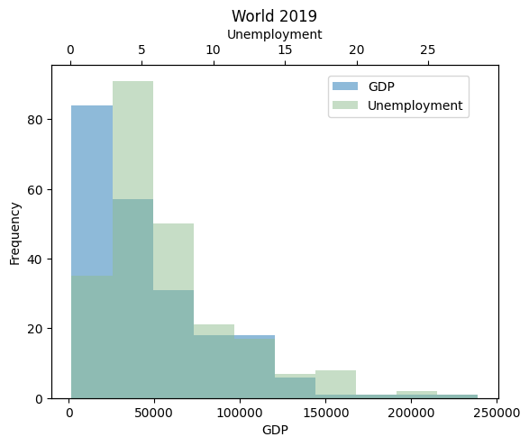

```python
# Matplotlib
fig,ax1 = plt.subplots()
ax1.hist(x='GDP',data=info2019,label='GDP',alpha=0.5)
ax1.set_xlabel('GDP')
ax1.set_ylabel('Frequency')

ax2 = ax1.twiny()
ax2.hist(x='Unemployment',data=info2019,label='Unemployment',alpha=0.5,
         color='darkseagreen')
ax2.set_xlabel('Unemployment')

plt.title('World 2019')
fig.legend(bbox_to_anchor=(0.86,0.87))
plt.show()
sns.set_palette('Spectral')
```

4. Almacena en un dataframe (**continents**), el contenido del archivo **Continents.csv**, que indica a qué continente y región pertence a cada país, y combínalo con el dataframe **info2019**, uslando la columna **Country Code**, para obtener el dataframe **continents_2019**.

```python
continents = pd.read_csv('Continents.csv')
continents
```

|  | Name | Country Code | Continent | Region |
| --- | --- | --- | --- | --- |
| 0 | Afghanistan | AFG | Asia | Southern Asia |
| 1 | Åland Islands | ALA | Europe | Northern Europe |
| 2 | Albania | ALB | Europe | Southern Europe |
| 3 | Algeria | DZA | Africa | Northern Africa |
| 4 | American Samoa | ASM | Oceania | Polynesia |
| ... | ... | ... | ... | ... |
| 244 | Wallis and Futuna | WLF | Oceania | Polynesia |
| 245 | Western Sahara | ESH | Africa | Northern Africa |
| 246 | Yemen | YEM | Asia | Western Asia |
| 247 | Zambia | ZMB | Africa | Sub-Saharan Africa |
| 248 | Zimbabwe | ZWE | Africa | Sub-Saharan Africa |

249 rows × 4 columns

```python
continents_2019 = info2019.merge(continents,on='Country Code')
continents_2019
```

|  | Country Code | GDP | Unemployment | Name | Continent | Region |
| --- | --- | --- | --- | --- | --- | --- |
| 0 | ABW | NaN | NaN | Aruba | Americas | Latin America and the Caribbean |
| 1 | AFG | 8246.351581 | 10.980000 | Afghanistan | Asia | Southern Asia |
| 2 | AGO | 17339.271710 | 6.930000 | Angola | Africa | Sub-Saharan Africa |
| 3 | ALB | 31009.390130 | 11.470000 | Albania | Europe | Southern Europe |
| 4 | AND | NaN | NaN | Andorra | Europe | Southern Europe |
| ... | ... | ... | ... | ... | ... | ... |
| 210 | WSM | 26153.906140 | 8.220000 | Samoa | Oceania | Polynesia |
| 211 | YEM | NaN | 12.900000 | Yemen | Asia | Western Asia |
| 212 | ZAF | 43799.052020 | 28.469999 | South Africa | Africa | Sub-Saharan Africa |
| 213 | ZMB | 9522.766264 | 11.910000 | Zambia | Africa | Sub-Saharan Africa |
| 214 | ZWE | 6213.323493 | 5.020000 | Zimbabwe | Africa | Sub-Saharan Africa |

215 rows × 6 columns

5. Del dataframe anterior, obtén los promedios por continente de ambos índices. Almacena el resultado en **continents_group**.

```python
continents_group = continents_2019.groupby(['Continent'])[['GDP','Unemployment']].mean()
continents_group
```

| Continent | GDP | Unemployment |
| --- | --- | --- |
| Africa | 16870.222166 | 8.358113 |
| Americas | 41861.482377 | 7.554849 |
| Asia | 52018.493888 | 5.709600 |
| Europe | 85926.422765 | 6.761282 |
| Oceania | 36056.567613 | 5.731818 |

6. Crea un matriz en la que vayas añadiendo las siguientes gráficas:

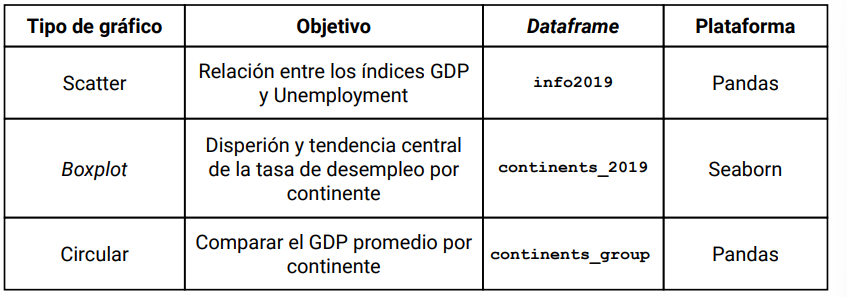

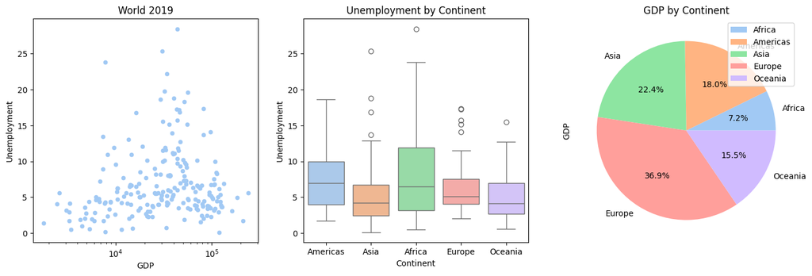

```python
sns.set_palette('pastel')
fig = plt.figure(figsize=(17,5))

ax1 = fig.add_subplot(131)
info2019.plot(kind='scatter',x='GDP',y='Unemployment',logx=True,ax=ax1)
ax1.set_title('World 2019')

ax2 = fig.add_subplot(132)
sns.boxplot(x='Continent',y='Unemployment',data=continents_2019,ax=ax2,
            hue='Continent')
ax2.set_title('Unemployment by Continent')

ax3 = fig.add_subplot(133)
continents_group.plot(kind='pie',y='GDP',autopct='%1.1f%%',ax=ax3)
ax3.set_title('GDP by Continent')

plt.show()
```

7. Almacena la información de México en un dataframe donde se almacene el PBI y el índice de desempleo para visualiar la evolución a través de los años.

```python
mexico_gdp = gdp[gdp['Country Code'] == 'MEX']
mexico_gdp.set_index('Country Code',inplace=True)
mexico_gdp = mexico_gdp.drop('Country Name',axis=1)
mexico_gdp = mexico_gdp.T
mexico_gdp.index.name = 'Year'
mexico_gdp.columns.name = ' '
mexico_gdp.columns = ['GDP']
mexico_gdp.head()
```

| Year | GDP |
| --- | --- |
| 1991 | 43868.90541 |
| 1992 | 43804.94070 |
| 1993 | 43077.84603 |
| 1994 | 44715.30806 |
| 1995 | 42238.58102 |

```python
mexico_unemployment = unemployment[unemployment['Country Code'] == 'MEX']
mexico_unemployment.set_index('Country Code',inplace=True)
mexico_unemployment = mexico_unemployment.drop('Country Name',axis=1)
mexico_unemployment = mexico_unemployment.T
mexico_unemployment.index.name = 'Year'
mexico_unemployment.columns.name = ''
mexico_unemployment.columns = ['Unemployment']
mexico_unemployment.head()
```

| Year | Unemployment |
| --- | --- |
| 1991 | 3.15 |
| 1992 | 3.24 |
| 1993 | 3.37 |
| 1994 | 4.44 |
| 1995 | 7.10 |

```python
mexico = mexico_gdp.join(mexico_unemployment)
mexico.head()
```

| Year | GDP | Unemployment |
| --- | --- | --- |
| 1991 | 43868.90541 | 3.15 |
| 1992 | 43804.94070 | 3.24 |
| 1993 | 43077.84603 | 3.37 |
| 1994 | 44715.30806 | 4.44 |
| 1995 | 42238.58102 | 7.10 |

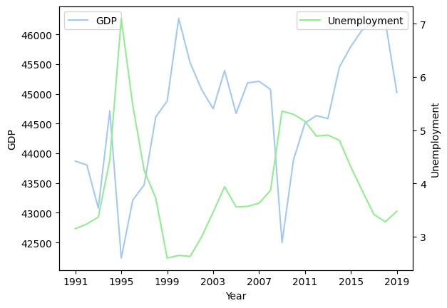

```python
sns.set_palette('pastel')

ax1 = sns.lineplot(x='Year',y='GDP',data=mexico,label='GDP')
ax1.set_ylabel('GDP')
ax1.set_xticks(np.arange(0,len(mexico)+1,4))

ax2 = ax1.twinx()
sns.lineplot(x='Year',y='Unemployment',data=mexico,label='Unemployment',
             color='lightgreen')
```